# Case Study: Is Russel Westbrook a good player in the 2021-22 Season?

By Teo Zeng

## Introduction: NBA

Started in the year of 1946, there had been a lot of great players, here are some that the author like the most:

### Lebron James

[figure not shown]

Lebron James

As of 2022, 37-year-old Lakers player Lebron James has won:

- 4x NBA champion (2012, 2013, 2016, 2020)
- 4x NBA Finals MVP (2012, 2013, 2016, 2020)
- 4x NBA Most Valuable Player (2009, 2010, 2012, 2013)
- 18x NBA All-Star (2005-2022)
- 3x NBA All-Star Game MVP (2006, 2008, 2018)
- 13x All-NBA First Team (2006, 2008-2018, 2020)

### Russel Westbrook

[figure not shown]

Russel Westbrook

As of 2022, 33-year-old Lakers point guard Russel Westbrook has won:

- NBA MVP (2017)
- 9x NBA All-Star (2011-2013, 2015-2020)
- 2x All-NBA First Team (2016, 2017)

## Motivation

On August 6, 2021, Westbrook was traded to the Los Angeles Lakers. As his first season with the Lakers progressed, Westbrook received criticism for his perceived poor quality of play. Westbrook shot 30 percent from the three-point line and turned the ball over 4.6 times per game through early January, and he received criticism for a particular game against the Minnesota Timberwolves where he turned the ball over nine times. Westbrook later responded to critics, saying that they were only looking at the stat sheet and not his overall play on the court.

However, Westbrook also had some remarkable games during the season. On January 4, 2022, in a 122-114 win over the Sacramento Kings, Westbrook had his first game without turnovers since March 14, 2016. On January 29, in a 114-117 loss to the Charlotte Hornets, he scored 35 points, of which 30 in the second half (16 points in the fourth quarter from a 20-point deficit) were the most by any Laker since Kobe Bryant’s last game on April 13, 2016.

**So the key question arises: Is Westbrook a good player in the 2021-22 season?**

For this case study, we **assume the fact that each player’s 2k rating is unbiased.** So to answer our case study question, we will use our model to predict the rating of Westbrook, base on his performance at the current season.

### An Overview of Dataset

The dataset is downloaded as a csv file and is obtained from a [kaggle dataset by William Yu](https://www.kaggle.com/datasets/willyiamyu/nba-2k-ratings-with-real-nba-stats).

While a full copy of the codebook is available in my zipped files, here are some of the key variables that are helpful to be aware of for this report:

- `PLAYER`: The name of the player
- `TEAM`: The name of the team
- `ratings`: The 2k rating of the player
- `GP`: The number of games played
- `MIN`: The number of minutes played
- `PTS`: The number of points scored
- `AST`: The number of assists
- `REB`: The number of rebounds
- `STL`: The number of steals
- `BLK`: The number of blocks
- `TOV`: The number of turnovers
- `PF`: The number of personal fouls
- `FG%`: The percentage of field goals made
- `3P%`: The percentage of three pointers made
- `FT%`: The percentage of free throws made

### Loading Data and Packages

We install some packages for data analysis.

```r
library(ggplot2)
library(tidymodels)
library(corrplot)
library(ggthemes)
library(yardstick)
library(tidyverse)
library(lubridate)
library(tidymodels)
library(skimr)
library(patchwork)
library(janitor)

tidymodels_prefer()

setwd("~/Desktop/PSTAT 131/pstat131-project")
set.seed(1205)
```

Then, we read the dataset.

```r
ratings <- read.csv(file = 'data/nba_rankings_2014-2020.csv')
```

```r
dim(ratings)
```

```
## [1] 2412   32
```

So we see that there are 2412 observations and 32 columns in total.

### Data Split

The data was split in a 80% training, 20% testing split.

```r
ratings_split <- ratings %>% initial_split(prop = 0.8)

ratings_train <- training(ratings_split)
ratings_test <- testing(ratings_split)
```

## Exploratory Data Analysis

### Teams

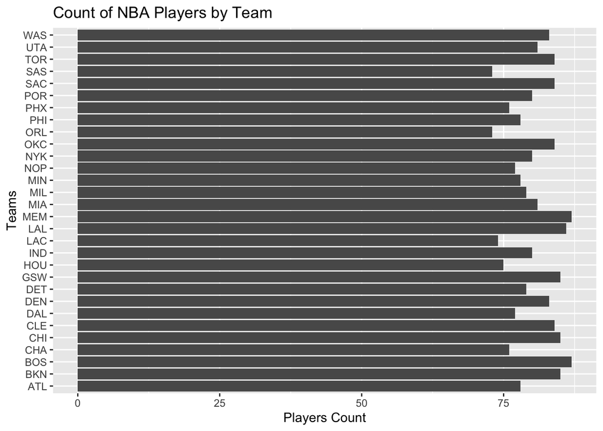

```r
ggplot(ratings, aes(TEAM)) +
  geom_bar() +
  labs(
    title = "Count of NBA Players by Team",
    x = "Teams",
    y = "Players Count"
  ) +
  # We want to be able to read labels better
  coord_flip()
```

So we see that over these years each team has about the same number of players. This makes sense because each NBA team has a minimum player number requirement each year.

### Ratings

Let’s examine `ratings` closely.

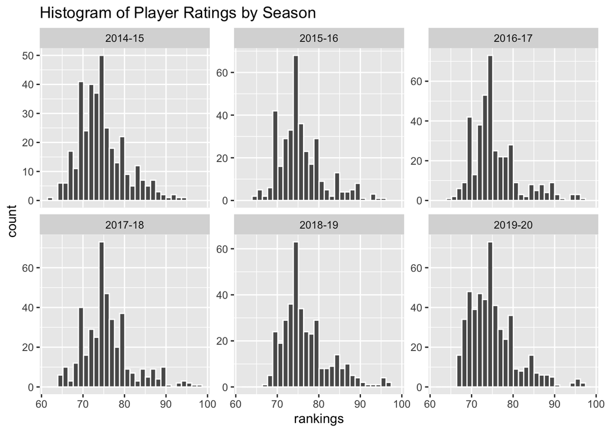

```r
ggplot(ratings, aes(rankings)) +
  geom_histogram(bins = 30, color = "white") +
  facet_wrap(~SEASON, scales = "free_y") +
  labs(
    title = "Histogram of Player Ratings by Season"
  )
```

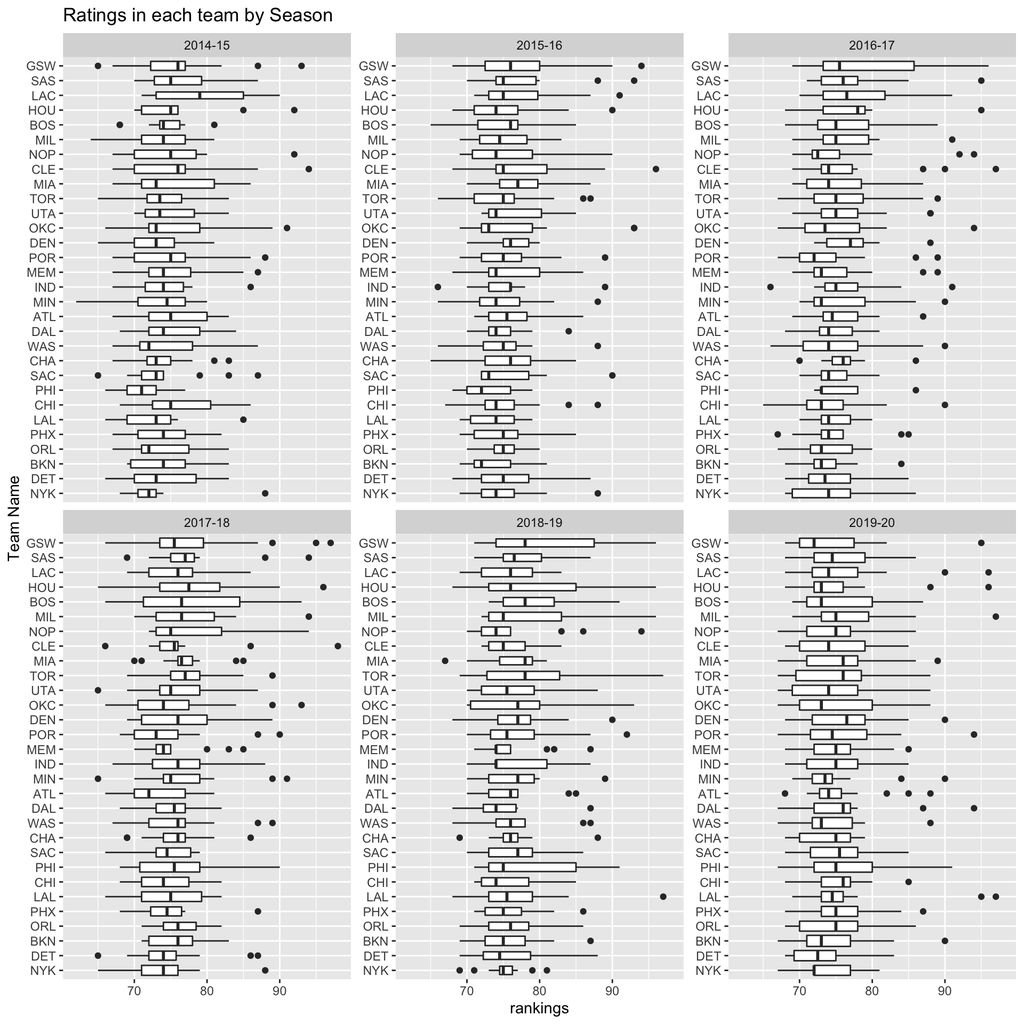

```r
ggplot(ratings, aes(reorder(TEAM, rankings), rankings)) +
  geom_boxplot(varwidth = TRUE) +
    facet_wrap(~SEASON, scales = "free_y") +
  coord_flip() +
  labs(
    title = "Ratings in each team by Season",
    x = "Team Name"
  )
```

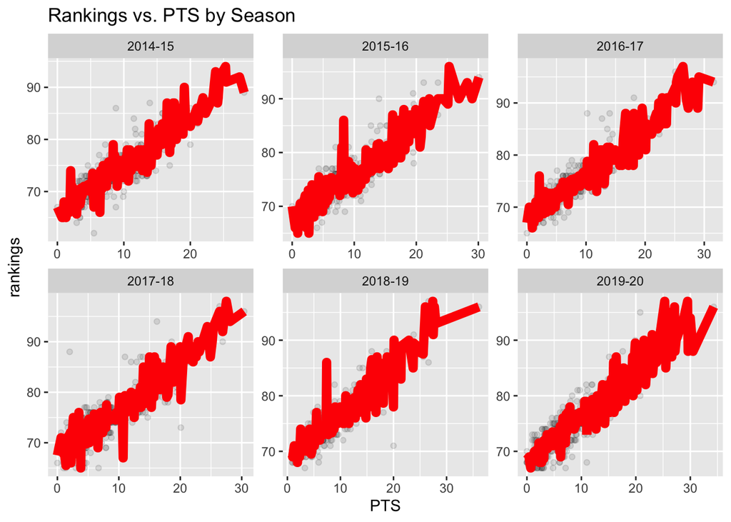

```r
ratings %>%
  ggplot(aes(PTS, rankings)) +
  geom_point(alpha = 0.1) +
  stat_summary(fun = mean, colour="red", geom="line", size = 3)+
  facet_wrap(~SEASON, scales = "free") +
  labs(
    title = "Rankings vs. PTS by Season"
  )
```